# Chapter 6 part III

Jose Luis Gonzalez

5/1/2018

### Problem 1

For generating $Y \sim ~N(0,1)$ using an Accept/Reject algorithm, we could generate $U \sim uniform$ and $V \sim exponential ( \lambda)$, and attach a random sign to V(+/- each with eqaul probability). The resulting V is the Double exponential familiy with density $g(x) = \lambda e^{-\lambda\mid x \mid}/2$ for $- \infty < x < \infty$.

#### a) Show that for any $\lambda> 0$ the double exponential density and the standard normal density intersect at a value of x >0 and a value of x < 0. This implies that the double exponential family does not dominate the standard normal density (By symmerty, it is sufficient to show this for x >0).

Suppose X > 0, set the standard normal and the double exponential equal to each other to find the X, at which they interesect.

$$(2\pi)^{-1/2}e^{-x^2/2} = \frac{\lambda e^{-\lambda x}}{2}$$

Take the natural log of both sides and move everything to one side.

$$\frac{x^2}{2} - \lambda x+ ln(\lambda) - ln(2) - \frac{ln(2 \pi)}{2} = 0$$

Multiply by 2 and simplify.

$$x^2 - 2 \lambda x+ ln(\frac{\lambda ^{2} \pi}{2}) = 0$$

Applying the quadratic formula, the solution to x is,

$$x = \lambda \pm \sqrt{\left( \lambda^2 - ln(\frac{\lambda \pi}{2})\right)}$$

The inside of the square root is greater than or equal to 0 for all $\lambda$. This implies that for x>0 there exist at least one point for which the standard normal and the double exponential are equal. When the inside of the square root is non-zero, then this implies that the two functions intersect at two different points. By symmetery, this result applys to x < 0.

#### b) In light of part(a), to have an envelope we need to set $e(x) = cg(x)$, for some c > 1. Find an optimal c for $\lambda = 1$ that minimizes the number of rejections.

In order to minimize the number of rejections we much find a $c$, such that, $f(x) = cg(x)$ only has two solutions for x, for $- \infty < x < \infty$. That is, the cg(x) sits on top of f(x) and is only tangant to f(x) at two points, so that $f(x) \leq g(x)$ for $- \infty < x < \infty$.

We do this by equating, $f(x) = cg(x)$, for $\lambda = 1$. We’ll compute c for x>0.

$$(2\pi)^{-1/2}e^{-x^2/2} = \frac{c e^{-x}}{2}$$
Take the natural log of both sides and move everything to one side.

$$\frac{x^2}{2} - x+ ln(c) - ln(2) - \frac{ln(2 \pi)}{2} = 0$$

Multiply by 2 and simplify.

$$x^2 - 2x+ ln(\frac{c \pi}{2}) = 0$$

Apply the quadratic equation and simplify.

$$x = 1 \pm \sqrt{\left(1- ln(\frac{c^2 \pi}{2}) \right)}$$

In order to minimize the number of rejections, we must choose c so that x = 1. In order to do this, we must solve the bottom equation.

$$1-ln(\frac{c^2 \pi}{2}) = 0$$

Solving for c in this equation yields,

$$c = \sqrt{\left(\frac{2 e^{1}}{\pi}\right)}$$

#### c) Apply the Accept/Reject algorithm to generate X from the standard normal distribution, by generating $U \sim uniform(0,1)$ and using

1. An envelope of Cauchy random variable
2. An envelope of double exponential random variable.
3. Compare the algorithms. Which one do you recommend?

Here is a plot of a standard normal distribution with a envelope of 1.6*cauchy(0,1)

```r
test = seq(-6,6,by =.001)
stdnorm = dnorm(test,0,1)
cauchy = 1.6*dcauchy(test)
```

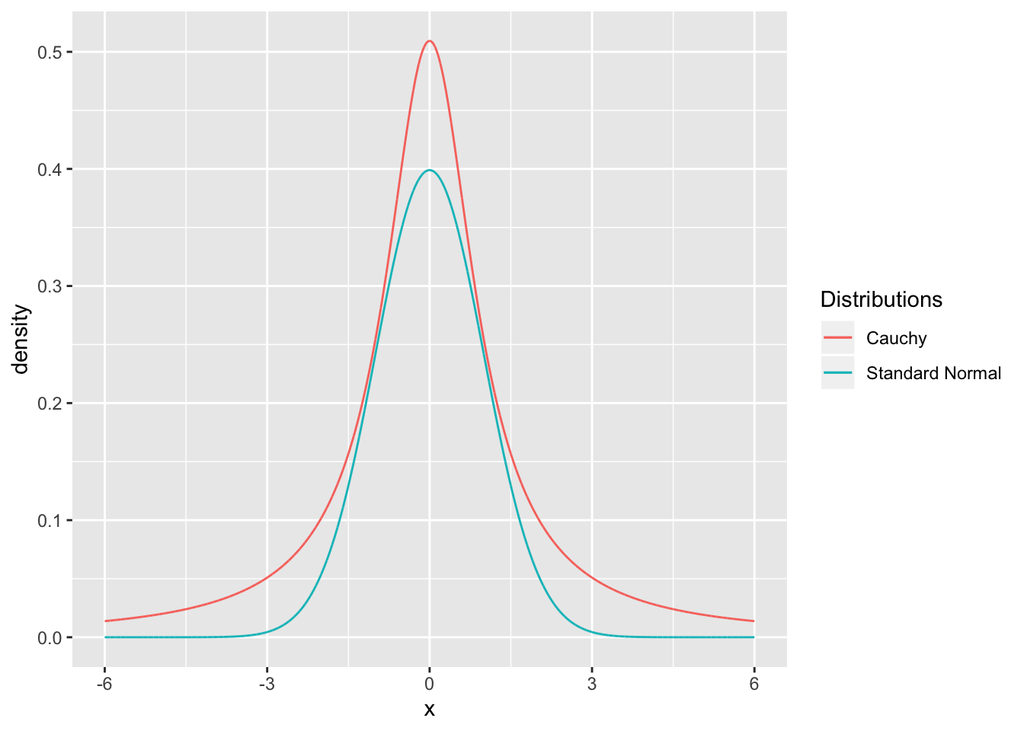

We’ll apply the Accept/Reject algorithm with 10,000 samples from cauchy(0,1)

```r
n = 10000
samp.chy = rcauchy(n)
u = runif(n)

f = dnorm(x = samp.chy)
g = 1.6*dcauchy(samp.chy) #envelope
X = samp.chy[which(u <(f/g))] # accepting
accepted.chy = length(X)# number of accepted points
```

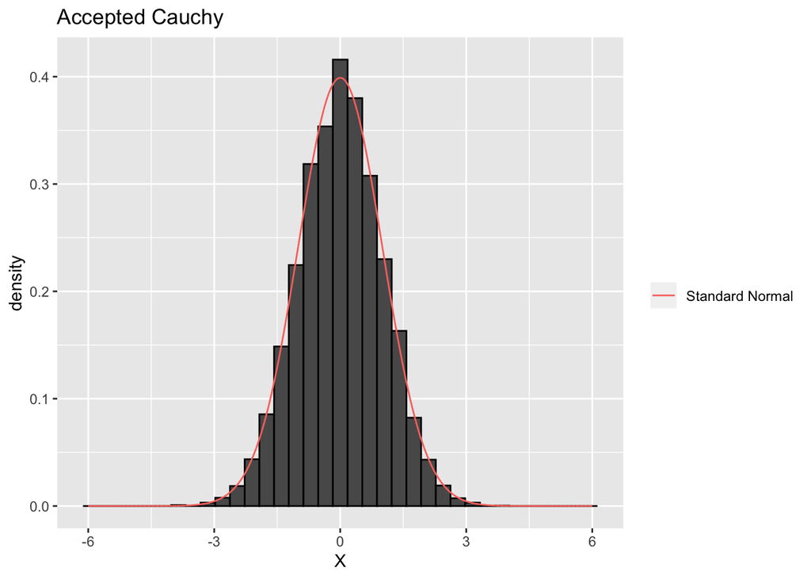

The number of accepted points under cauchy(0,1) is: 6286

Now we’ll calculate an envelope of double exponential. We will use dlaplace from the rmulti package for our double exponential distribution.

```r
test = seq(-6,6,by =.001)
library(rmutil)
# testing our dbexp with dlaplace
y = dlaplace(test)
c = sqrt((2*exp(1))/pi)
z = c*y
```

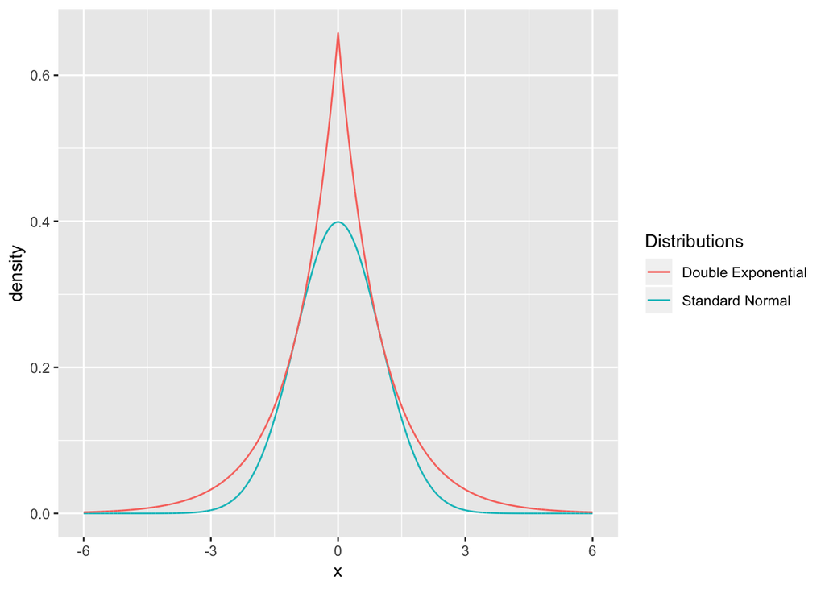

```r
n = 10000
samp.dbexp = rlaplace(n)
u= runif(n)

f = dnorm(x = samp.dbexp)
c = sqrt((2*exp(1))/pi) # optimal c
g = c*dlaplace(samp.dbexp) # envelope
X = samp.dbexp[which(u <(f/g))] # accepting
accepted.dbexp = length(X) # number of accepted points
```

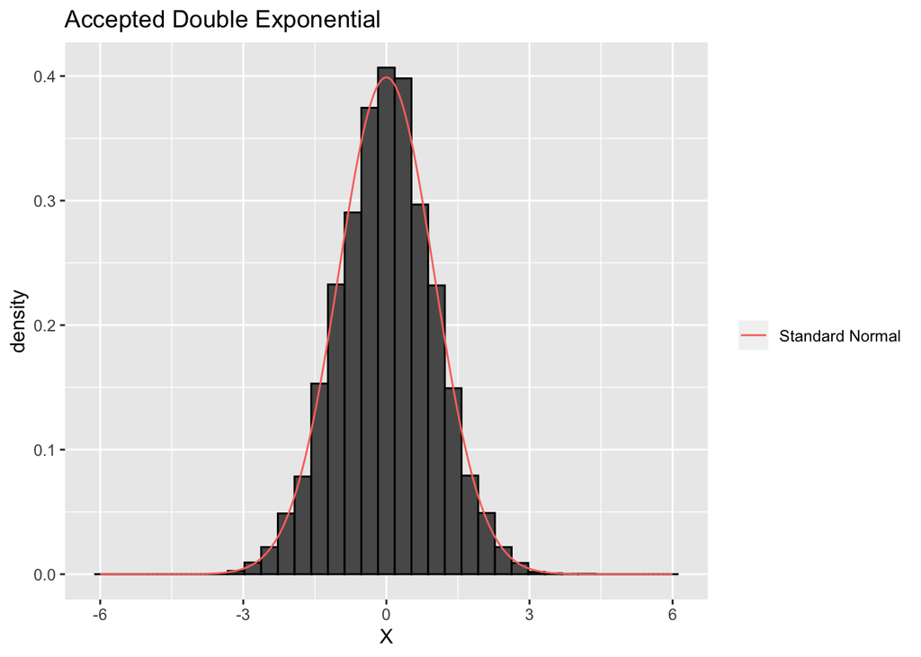

The number of accepted points under double exponential is: 7614

Upon inspection, I would recommend the use of the double exponential because it rejected less sample points and was therefore more efficient.

|  | Accepted |
| --- | --- |
| Cauchy | 6286 |
| Double Accepted | 7614 |

### Problem 2: Do problem 6.4 a) of the text.

Below is the code for obtaining the posterior distribution through SIR.

```r
coal = read.table("/Users/josegonzalez/Documents/R/coal.dat", header = TRUE)
m = 10000 # number of draws from prior
theta = sample(c(1:111), size = m, replace = TRUE)
a1 = rgamma(m,10,10); a2 = rgamma(m,10,10);
lam1 = rgamma(m,3,a1); lam2 = rgamma(m,3,a2)

parm = cbind(theta, lam1, lam2)


like = function(par, X = coal$disasters){
  par = as.numeric(par)
  # par is a row containing: theta_i, lam1_i, lam2_i
  t = par[1]; l1 = par[2]; l2 = par[3];
  temp1 = X[1:t]; temp2 = X[(t+1):112];
  l = -t*l1 + log(l1)*sum(temp1) - (112-t)*l2 + log(l2)*sum(temp2) # loglike
  exp(l) #likelihood
}

l = apply(parm, MARGIN = 1, function(x) like(x))


weights = l/sum(l)
resamp = sample(c(1:m), m, replace = TRUE, prob = weights)
post = parm[resamp, ]
```

The posterior mean’s for theta, lambda1, and lambda2 are:

```r
# post mean for parameters, histogram of theta, and credible interval for theta
post_mean = apply(post, 2, mean)
```

|  | Posterior Mean |
| --- | --- |
| theta | 40.3984000 |
| lam1 | 3.0942197 |
| lam2 | 0.9900696 |

Below is a histogram of the posterior distribution of theta.

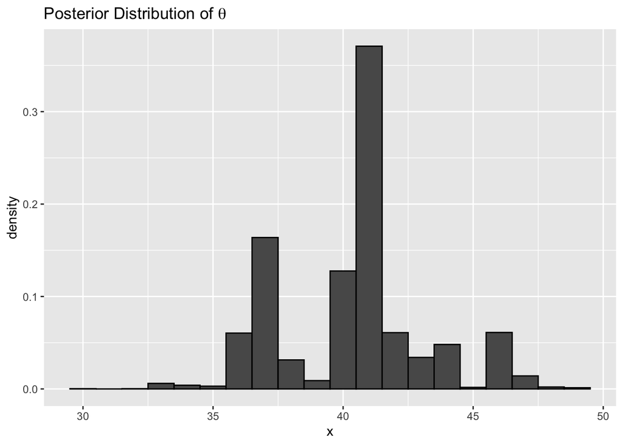

The 95% credible interval is found using quantile. The interval is in between the following two numbers.

|  | Theta |
| --- | --- |
| 2.5% | 36 |
| 97.5% | 46 |

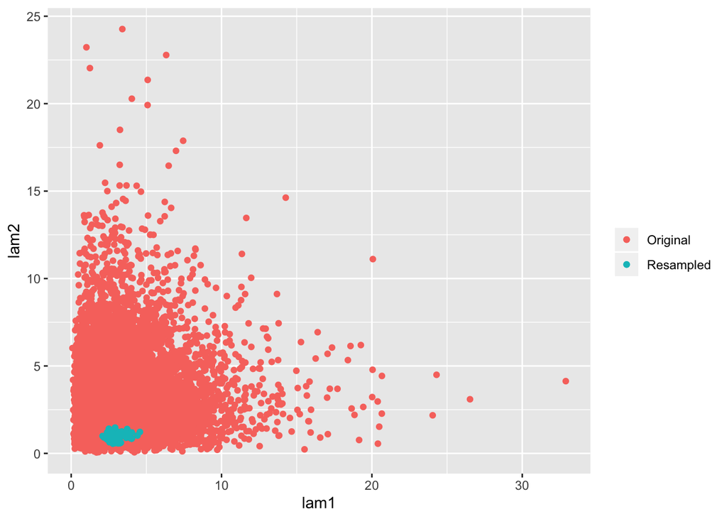

The initial and resampling sample sizes are the same, 10000. The number of unique points, tables of counts, and highest observed frequency in resample are as follows:

| Number of Unique Points | 19 |
| --- | --- |

| Observation.Var1 | Observation.Freq |
| --- | --- |
| 30 | 3 |
| 32 | 3 |
| 33 | 60 |
| 34 | 40 |
| 35 | 30 |
| 36 | 604 |
| 37 | 1638 |
| 38 | 314 |
| 39 | 90 |
| 40 | 1276 |
| 41 | 3708 |
| 42 | 609 |
| 43 | 341 |
| 44 | 481 |
| 45 | 17 |
| 46 | 611 |
| 47 | 141 |
| 48 | 21 |
| 49 | 13 |

|  | Observation.with.Maximum.Frequency |
| --- | --- |
| 41 | 0.3708 |